# Day 2 Lab Solutions: Inversion formula and rejection sampling

2022-07-12

**1.** We will use the inversion method to sample from a Cauchy distribution.

**1a.** Recall the pdf and cdf of Cauchy(t, s):  
$f(x) = \frac{1}{s\pi(1 + (x-t)^2/s^2)}$,  
$F(x) = \frac{1}{2} + \frac{1}{\pi}\tan^{-1}(\frac{x-t}{s})$.  
Find the inverse of the cdf.

**1a. Solution**
We want to find the inverse inverse of the cdf, $x = F^{-1}(u)$.
$$\begin{equation*}
\begin{split}
F(x) &= u\\
\frac{1}{2} + \frac{1}{\pi}\tan^{-1}(\frac{x-t}{s}) &= u \\
\frac{1}{\pi}\tan^{-1}(\frac{x-t}{s}) &= u - \frac{1}{2} \\
\tan^{-1}(\frac{x-t}{s}) &= \pi(u - \frac{1}{2}) \\
\frac{x-t}{s} &= \tan(\pi(u - \frac{1}{2})) \\
x-t &= s\tan(\pi(u - \frac{1}{2})) \\
x &= s\tan(\pi(u - \frac{1}{2})) + t\\
\end{split}
\end{equation*}$$

**1b. Solution**

```r
set.seed(2431)
u <- runif(20000)

t <- 1
s <- 0.75
x <- s * tan(pi *(u - 0.5)) + t
```

**1c.** Make a histogram of your samples obtained using the inversion formula. Compare your histogram to the one below, generated by directly drawing random samples using `rcauchy()`.

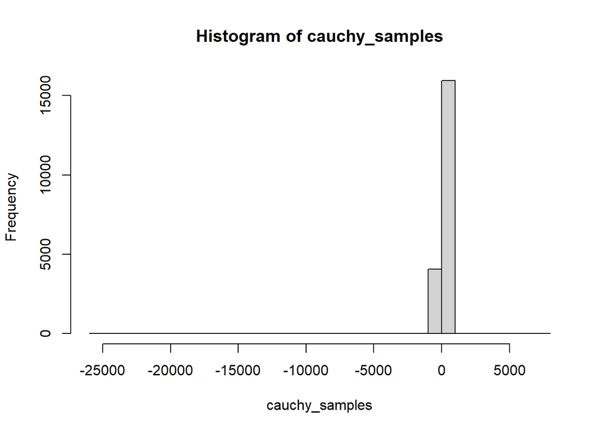

```r
cauchy_samples <- rcauchy(n = 20000, location = 1, scale = 0.75)
hist(cauchy_samples, breaks = 30)
```

**1c. Solution**

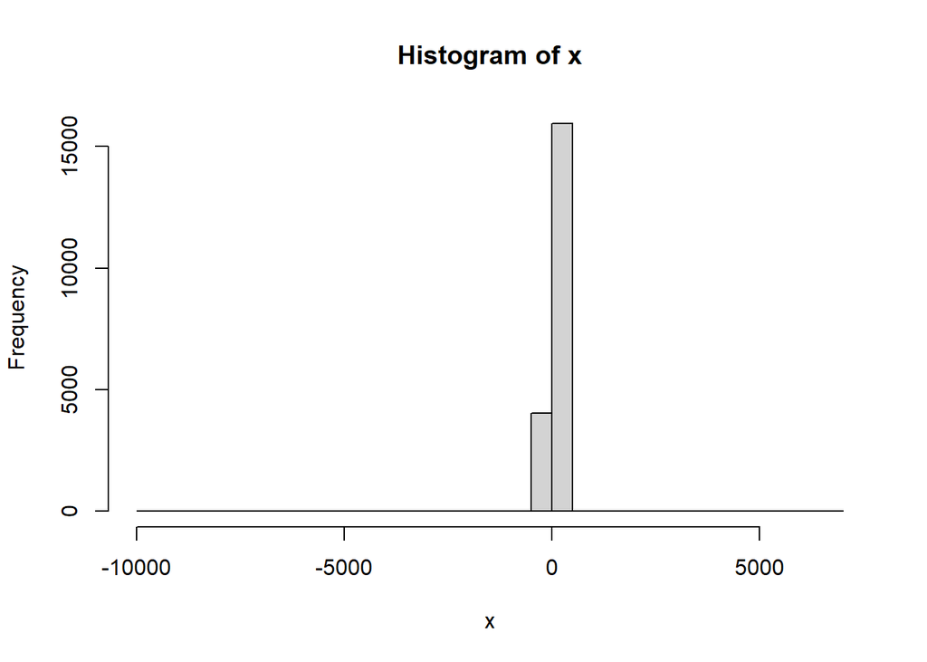

```r
hist(x, breaks = 30)
```

They look similar with values concentrated around 0, with the exception of some extreme values we did not sample.

**2.** Suppose we want to sample from the pdf
$$f(x) = 1.2 - x^4$$

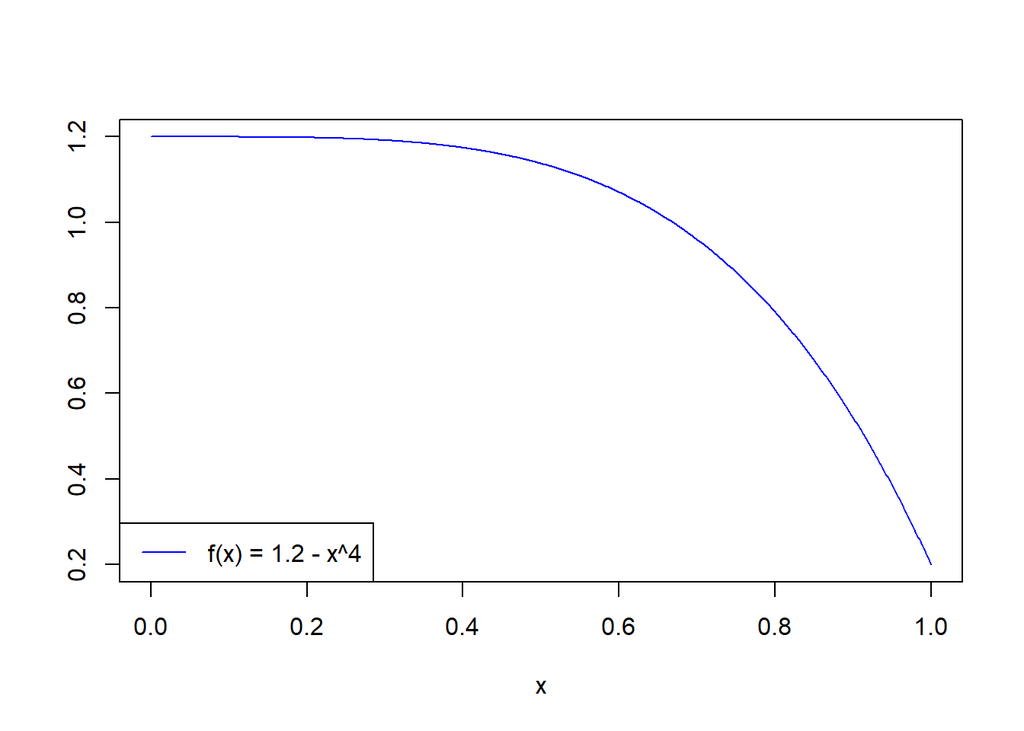

We will use rejection sampling to sample from this distrbution.

**2a.** First we need a proposal density, $q(x)$, that covers our target density. The support (i.e. possible values of x) of the target density is (0, 1). One possible proposal density is a standard uniform density since it is also (0, 1), and we know the support of the target density must be a subset of the support of the proposal density.

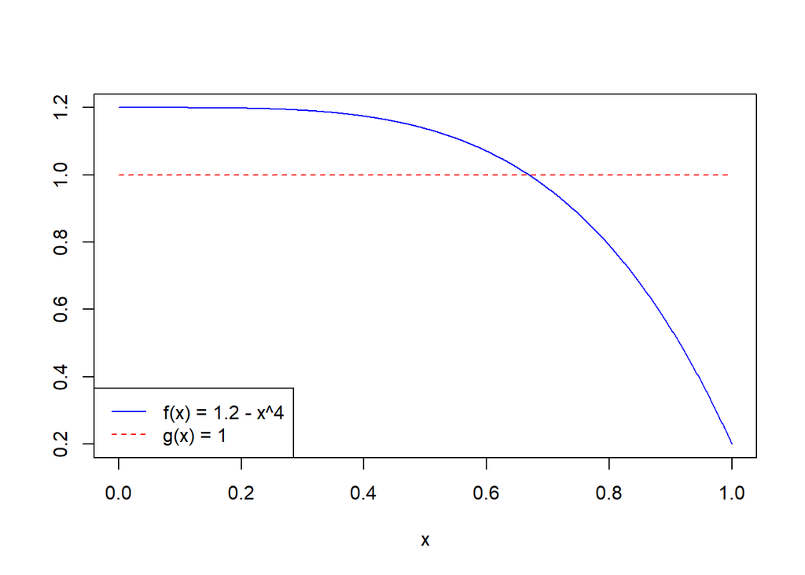

**2a. Solution**  
Having $M$ be any value greater than or equal to the max of $f(x)$ would work. For efficiency, to reject the fewest number of samples with this proposal distribution we would want to choose $M = \max(f(x)) = 1.2$.

**2b.** For our chosen $M$ we will now generate random uniform(0, 1) samples, $u$ and accept the sample if
$$u \leq \frac{f(x)}{Mg(x)}$$
. Do this sampling until you get 10,000 samples from our target distribution. Comment on what proportion of you samples from $q(x)$ were accepted as samples from $f(x)$.

**2b. Solution**

```r
target_n <- 10000

num_iterations <- 0
num_accepted <- 0

M <- 1.2

f_samples <- rep(NA, target_n)

while(num_accepted < target_n & num_iterations < 100000) {
  g_sample <- runif(1)
  u <- runif(1)

  if (u <= (1.2 - g_sample^4) / (M * 1)) {
    num_accepted <- num_accepted + 1
    f_samples[num_accepted] <- g_sample
  }

  num_iterations <- num_iterations + 1
}

percent_accepted <- 100 * num_accepted / num_iterations
```

83.47% of my proposed samples were accepted.

**2c.** Plot a histogram of your samples from the target distribution. Do your samples look like they came from the target distribution?

**2c. Solution**

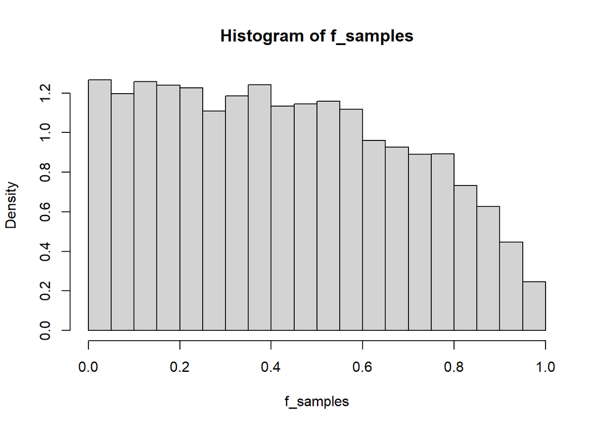

```r
hist(f_samples, freq = FALSE)
```

Yes, they do look like samples from the target distribution.

**2d.** How would the percent of accepted sample change is we used a larger $M$? What about if we chose to use a Uniform(0, 3) as our proposal distribution?

**2d. Solution**  
If we used a larger $M$ we would increase the rejection region so the percent of accepted samples would decrease. Similarly, our rejection region would increase if we chose Uniform(0,3) as our proposal distribution since we would be increasing the range of possible values drawn, but still only keeping values between 0 and 1.